# Remove all error sequences results

Hannah Swan

December 5, 2024

Okay note: the dollar sign weirdness are how things are showing up in the rowdata from Ernesto so it has something to do with how he processed the data. Is not because you named the files in a weird way or anything.

```
## There are 1007 unique miRNAs in Ernesto's benchmark dataset.
```

```
## Algorithm ran successfully for 946 unique miRNAs
```

Don’t need to evaluate this part because right now the functions are returning a lot of things in list format and we also have a lot of them, so loading them all takes a lot of memory. Already extracted what we want from them and wrote them to different .Rds files.

## Load all partition objects

Ok i take it back this is too big and we end up crashing R will load on an as needed basis

#Get the things we’re going to need

```r
partitions = readRDS("/scratch/hswan/thesis_isomiR_count_denoising/rmv_all_err_seqs/results/partition_results.Rds")
num_iters_ran = readRDS("/scratch/hswan/thesis_isomiR_count_denoising/rmv_all_err_seqs/results/num_iters_ran.Rds") %>% unlist() %>% unname()
```

For each partition object, get the number of iterations it ran for

```
## Number of iterations run to remove all error sequences:
```

```
## num_iters_ran
##   1   2   3   4   5   6   7   8   9  10  11  12  13  14  15  16  17  18  19
## 173  39  41  66  69  80  71 100  91  76  49  36  23   9  11   3   3   3   1
```

```
## Mean number of iterations run to remove all error sequences: 6.432203
```

Make a plot of the distribution of number of iterations ran:

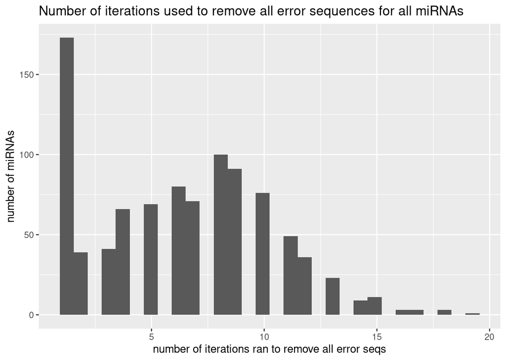

Also for each partition, get the number of partitions created

```
## Number of true isomiR sequences identified for each miRNA
```

```
## num_partitions
##   1   2   3   4   5   6   7   8   9  10  11  12  13  14  15  16  17  18  19  20
## 173  39  28  37  32  25  16  25  23  14  23  13  10  14  13  10  12  10   9  11
##  21  22  23  24  25  26  27  28  29  30  31  32  33  34  35  36  37  38  39  40
##   8  12  10   3   5  10   7   9   4   6   8   7   8   5   2   6   6   4   7   7
##  41  42  43  44  45  46  47  48  49  50  51  52  53  54  55  56  57  58  59  60
##   7   7   4   9   6   4   6   3   1   7   2   2   4   4   5   4   5   3   4   1
##  61  62  63  64  65  66  67  68  70  71  73  74  75  76  77  78  79  80  81  83
##   3   3   3   2   2   4   2   4   2   3   1   3   2   3   5   5   3   1   1   3
##  84  85  86  87  89  90  91  92  93  95  97  99 100 101 102 104 105 106 107 108
##   1   1   1   3   2   4   1   1   1   1   3   1   1   3   1   1   2   1   2   1
## 110 111 112 113 114 115 116 117 118 119 120 124 125 126 128 130 131 134 135 138
##   3   2   2   1   1   2   2   1   2   1   2   1   2   1   1   2   1   1   1   1
## 139 141 145 146 147 148 152 156 157 161 164 166 167 168 169 179 184 185 203 208
##   1   1   1   1   1   1   1   1   1   1   1   1   2   1   1   1   2   1   1   1
## 209 213 215 217 218 221 223 230 234 236 238 246 248 251 254 257 259 261 272 273
##   1   2   2   1   1   1   1   1   1   1   1   1   1   1   1   1   1   1   1   1
## 284 285 287 290 293 297 309 316 318 332 353 394 402 403 557 608 618 664 699 700
##   1   1   1   1   1   1   1   1   1   1   1   1   1   1   1   1   1   1   1   1
## 725 785 792 876
##   1   1   1   1
```

Make a plot of the number of partitions created:

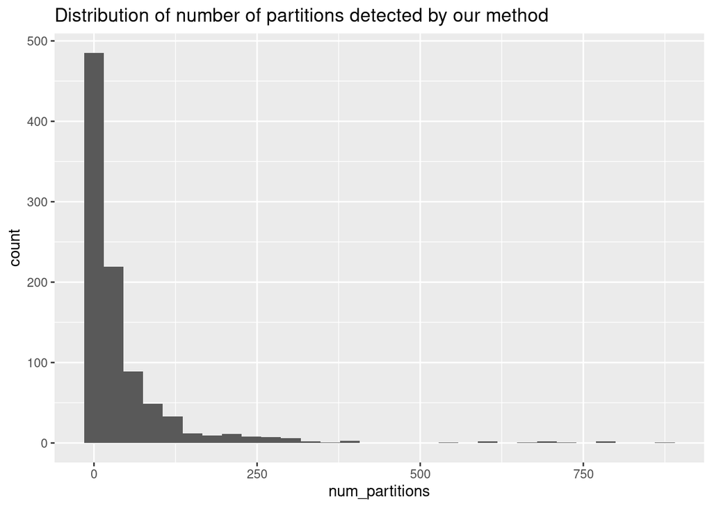

Definitely skewed towards creating a small number of partitions, which makes sense because we’re assuming that true isomiR sequences are rare. Some miRNAs have more than 750 partitions being created. That might sound like a lot and maybe a cause for concern, but at the same time some miRNAs have 10s of 1000s of sequences mapping to them so it’s not an immediate cause for concern.

Also curious what the proportion of true isomiR sequences identified by our method to the total number of sequences mapping to that miRNA is. I think this might be a better metric for helping us evaluate performance because of the comment above. You might see a large number of partitions being created for a certain miRNA and think that its cause for alarm because it looks like the performance violates our assumption that true isomiRs are rare. As long as the only miRNAs where we see the proportion of true isomiR sequences to total number of sequences mapping to that miRNA is 1 are miRNAs where we only have 1 sequence mapping to that miRNA, we’re okay at this point.

```
## [1] 0.14341085 0.62500000 0.04939064 1.00000000 1.00000000 1.00000000
```

```
## Minimum proportion of true isomiR sequences identified: 0.001277139
```

```
## Maximum proportion of true isomiR sequences identified: 1
```

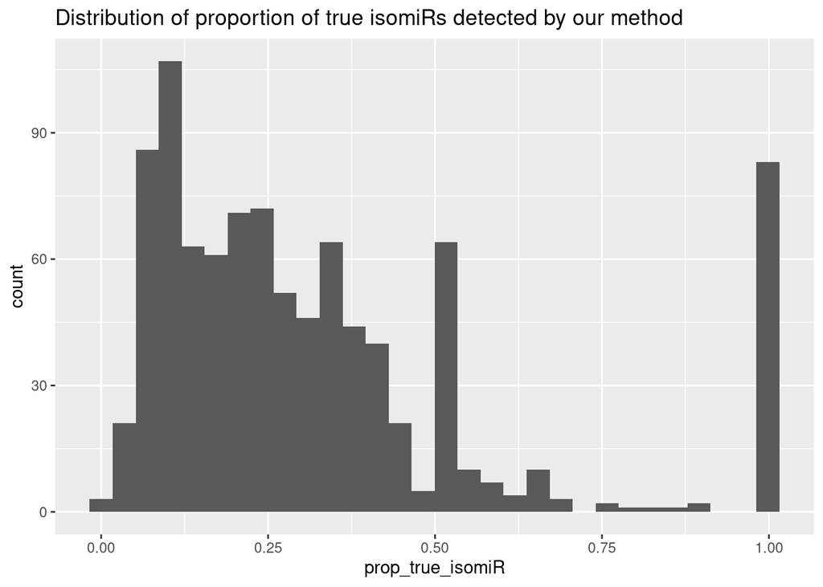

## Examining miRNAs where every unique sequence has been identified as a true isomiR

Is there a good reason for this? One reason we see this is that there is only 1 sequence mapping to that miRNA as mentioned above. Sort of a weird edge case. Another thing that can happen is that we have a low read count for a small number of sequences. E.g. suppose we have 3 unique sequences mapping to a miRNA with observed read counts $y_1 = 2, y_2 = 2, y_3 =3$. Initially we will create 1 partition with sequence 3 being the center sequence. But because we have such small read counts, it looks like we have, say, a degradation rate of $2/3$ in comparison to a much smaller degradation rate according to the transition probability matrix. Therefore, each sequence will likely get its own partition. Is this valid?

```
## .
##  1  2  3  4
## 65 10  4  4
```

```
## miRNA: Mmu-Let-7-P1b_5p$Mmu-Let-7-P1c_5p$Mmu-Let-7-P1d_5p$Mmu-Let-7-P2a1_5p$Mmu-Let-7-P2a2_5p$Mmu-Let-7-P2b2_5p
##     uniqueSequence
## 1 TGAGGTAGAAGGTTGT
## 2  TGAGGTAGAAGGTTG
## 3 TGAGGTAGCAGGTTGT
## 4  TGAGGTAGCAGGTTG
##                                                                                                 miRNA_name
## 1 Mmu-Let-7-P1b_5p$Mmu-Let-7-P1c_5p$Mmu-Let-7-P1d_5p$Mmu-Let-7-P2a1_5p$Mmu-Let-7-P2a2_5p$Mmu-Let-7-P2b2_5p
## 2 Mmu-Let-7-P1b_5p$Mmu-Let-7-P1c_5p$Mmu-Let-7-P1d_5p$Mmu-Let-7-P2a1_5p$Mmu-Let-7-P2a2_5p$Mmu-Let-7-P2b2_5p
## 3 Mmu-Let-7-P1b_5p$Mmu-Let-7-P1c_5p$Mmu-Let-7-P1d_5p$Mmu-Let-7-P2a1_5p$Mmu-Let-7-P2a2_5p$Mmu-Let-7-P2b2_5p
## 4 Mmu-Let-7-P1b_5p$Mmu-Let-7-P1c_5p$Mmu-Let-7-P1d_5p$Mmu-Let-7-P2a1_5p$Mmu-Let-7-P2a2_5p$Mmu-Let-7-P2b2_5p
##   count partition center
## 1     6         3      1
## 2     3         4      1
## 3    49         1      1
## 4     9         2      1
## miRNA: Mmu-Let-7-P1b_5p$Mmu-Let-7-P1c_5p$Mmu-Let-7-P1d_5p$Mmu-Let-7-P2a1_5p$Mmu-Let-7-P2a2_5p$Mmu-Let-7-P2b2_5p$Mmu-Let-7-P2c2_5p$Mmu-Let-7-P2c3_5p
##      uniqueSequence
## 1 CTGAGGTAGTAGGTTGT
## 2  CTGAGGTAGTAGGTTG
## 3   CTGAGGTAGTAGGTT
##                                                                                                                                     miRNA_name
## 1 Mmu-Let-7-P1b_5p$Mmu-Let-7-P1c_5p$Mmu-Let-7-P1d_5p$Mmu-Let-7-P2a1_5p$Mmu-Let-7-P2a2_5p$Mmu-Let-7-P2b2_5p$Mmu-Let-7-P2c2_5p$Mmu-Let-7-P2c3_5p
## 2 Mmu-Let-7-P1b_5p$Mmu-Let-7-P1c_5p$Mmu-Let-7-P1d_5p$Mmu-Let-7-P2a1_5p$Mmu-Let-7-P2a2_5p$Mmu-Let-7-P2b2_5p$Mmu-Let-7-P2c2_5p$Mmu-Let-7-P2c3_5p
## 3 Mmu-Let-7-P1b_5p$Mmu-Let-7-P1c_5p$Mmu-Let-7-P1d_5p$Mmu-Let-7-P2a1_5p$Mmu-Let-7-P2a2_5p$Mmu-Let-7-P2b2_5p$Mmu-Let-7-P2c2_5p$Mmu-Let-7-P2c3_5p
##   count partition center
## 1     9         2      1
## 2     6         3      1
## 3    49         1      1
## miRNA: Mmu-Let-7-P1b_5p$Mmu-Let-7-P1c_5p$Mmu-Let-7-P1d_5p$Mmu-Let-7-P2a1_5p$Mmu-Let-7-P2a2_5p$Mmu-Let-7-P2c3_5p
##       uniqueSequence
## 1 CTGAGGTAGTAGGTTGTA
##                                                                                                 miRNA_name
## 1 Mmu-Let-7-P1b_5p$Mmu-Let-7-P1c_5p$Mmu-Let-7-P1d_5p$Mmu-Let-7-P2a1_5p$Mmu-Let-7-P2a2_5p$Mmu-Let-7-P2c3_5p
##   count partition center
## 1    19         1      1
## miRNA: Mmu-Let-7-P1b_5p$Mmu-Let-7-P1d_5p$Mmu-Let-7-P2a1_5p$Mmu-Let-7-P2b1_5p
##     uniqueSequence
## 1 GTAGGTTGTATAGTTG
##                                                              miRNA_name count
## 1 Mmu-Let-7-P1b_5p$Mmu-Let-7-P1d_5p$Mmu-Let-7-P2a1_5p$Mmu-Let-7-P2b1_5p     2
##   partition center
## 1         1      1
## miRNA: Mmu-Let-7-P1b_5p$Mmu-Let-7-P2b2_5p
##       uniqueSequence                         miRNA_name count partition center
## 1 TGAGGTAGGAGGTTGTGT Mmu-Let-7-P1b_5p$Mmu-Let-7-P2b2_5p   224         1      1
## 2  TGAGGTAGGAGGTTGTG Mmu-Let-7-P1b_5p$Mmu-Let-7-P2b2_5p    68         2      1
## miRNA: Mmu-Let-7-P1b_5p$Mmu-Let-7-P2c3_5p
##      uniqueSequence                         miRNA_name count partition center
## 1 TGAGGTAGGAGTTTGTA Mmu-Let-7-P1b_5p$Mmu-Let-7-P2c3_5p     5         1      1
```

```r
cat("Testing function with Bonferroni adjustment for miRNA", miRNA, "\n")
```

```
## Testing function with Bonferroni adjustment for miRNA Mmu-Let-7-P1b_5p$Mmu-Let-7-P2c3_5p
```

```r
tst = denoise_isomiR_counts(rowdata, count_df, transition_probs, miRNA, 0.05, 5, "Bonferroni")
```

```
## Creating initial partition_df object for miRNA Mmu-Let-7-P1b_5p$Mmu-Let-7-P2c3_5p
## Getting initial alignments
## Getting initial transitions
## Calculating initial lambdas
## Beginning iteration 1
## Computing abundance p-values
## Partition 1 center sequence has observed read count 5
## Partition 1 contains 0 non center sequences.
## Adjusting for multiple testing and getting hypothesis testing results
## Adjusting for multiple testing using Bonferroni
## No new partitions created.
## Ending at iteration 1
```

```r
tst_BH = denoise_isomiR_counts(rowdata, count_df, transition_probs, miRNA, 0.05, 5, "BH")
```

```
## Creating initial partition_df object for miRNA Mmu-Let-7-P1b_5p$Mmu-Let-7-P2c3_5p
## Getting initial alignments
## Getting initial transitions
## Calculating initial lambdas
## Beginning iteration 1
## Computing abundance p-values
## Partition 1 center sequence has observed read count 5
## Partition 1 contains 0 non center sequences.
## Adjusting for multiple testing and getting hypothesis testing results
## Adjusting for multiple testing using Benjamini-Hochberg procedure
## No new partitions created.
## Ending at iteration 1
```

Compare the 2

```
## Bonferroni:
```

```
##
## 1
## 1
```

```
## Benjamini-Hochberg:
```

```
##
## 1
## 1
```

So same number of partitions results from using both methods for adjusting for multiple testing.

Number of iterations run for both:

[output not shown]

[output not shown]

```
## Do we end up with the exact same partitions from the two methods?
```

```
## Yes
```

Curious about the relationship to other center sequences that we have. How different is a newly identified center sequence from the center of its partition?

```r
#take first partitions object
partition_df = partitions[[1]]

#take center sequence of first partition
center_seq = filter(partition_df, partition == 1 & center == 1) %>% select(., uniqueSequence) %>% unlist() %>% unname()

#take other center sequences:
seqs = filter(partition_df, partition != 1 & center==1) %>% select(., uniqueSequence) %>% unlist() %>% unname()

a = pairwiseAlignment(pattern=center_seq, seqs[4])
print(a)
```

```
## Global PairwiseAlignmentsSingleSubject (1 of 1)
## pattern: --CTATACGGCCTCCTAGCTTTCT
## subject: CACTATACGGCCTCC--------T
## score: -32.25542
```

```r
t = get_transitions(a)

#initialize different variables  for describing relationship between 2 seqs
num_subs = 0
num_dels = 0
num_ins = 0

for(i in 1:ncol(t)){
  trns = get_transition_at_idx(i, t)
  x = trns$x
  y = trns$y
  if(x == "-" & y != "-"){
    num_ins = num_ins +1
  } else if(x != "-" & y == "-"){
    num_dels = num_dels + 1
  } else if(x != "-"  & y != "-" & x != y){
    num_subs = num_subs + 1
  }
}

cat("Number of substitutions:", num_subs, "\n")
```

```
## Number of substitutions: 0
```

```r
cat("Number of insertions:", num_ins, "\n")
```

```
## Number of insertions: 2
```

```r
cat("Number of deletions", num_dels, "\n")
```

```
## Number of deletions 8
```

Small number of sequences mapping to this miRNA so we can look at all rows in the partition_df object

```
##      uniqueSequence                         miRNA_name count partition center
## 1 TGAGGTAGGAGTTTGTA Mmu-Let-7-P1b_5p$Mmu-Let-7-P2c3_5p     5         1      1
```

Look at the sequences and the alignments in each partition - are length variants / mixed type isomiRs more likely to get their own partition while sequence variants are more likely to stay in the same partition?

Does the length of the center sequence decrease as the partition being created increases?

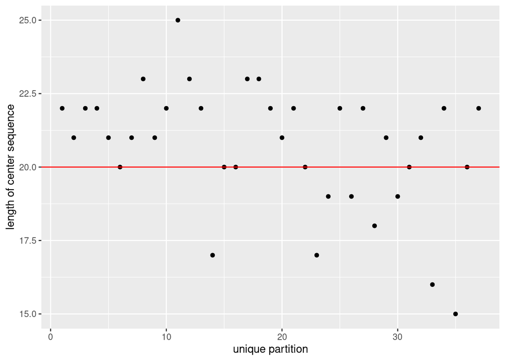

It doesn’t really look like there’s any pattern here, which is good.

Is there a relationship between the observed read count of center sequences identified later and the partition being created?

```
## [1] 1744 1448   90 1679  110  804
```

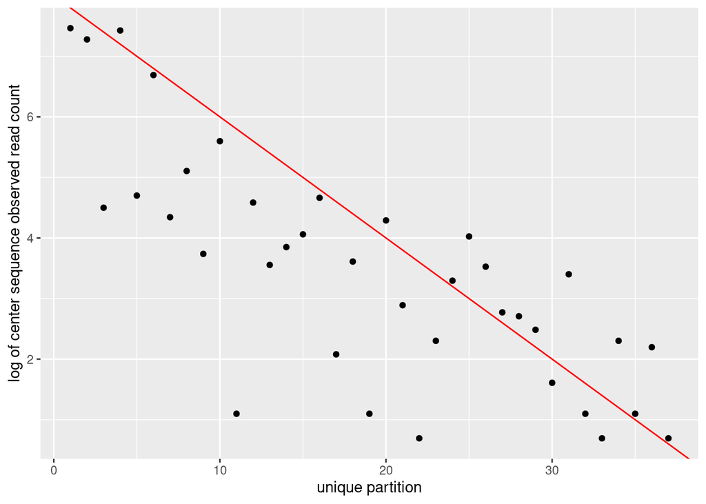

It does look like there is a decreasing trend here - as we move into later iterations we’re selecting center sequences with smaller observed read counts. This is just for one miRNA but we likely see it in others as well:

```r
partition_df = partitions[[2]]
cat("Unique partitions created for miRNA", partition_df$miRNA_name[1], "\n")
```

```
## Unique partitions created for miRNA Mmu-Let-7-P1b_3p*$Mmu-Let-7-P1d_3p*
```

```r
unique_partitions = unique(partition_df$partition) %>% sort()
cat("According to our model, there are unique", max(unique_partitions), "isomiR sequences mapping to this miRNA.\n")
```

```
## According to our model, there are unique 5 isomiR sequences mapping to this miRNA.
```

```r
cat("There are", nrow(partition_df), "total sequences mapping to this miRNA")
```

```
## There are 8 total sequences mapping to this miRNA
```

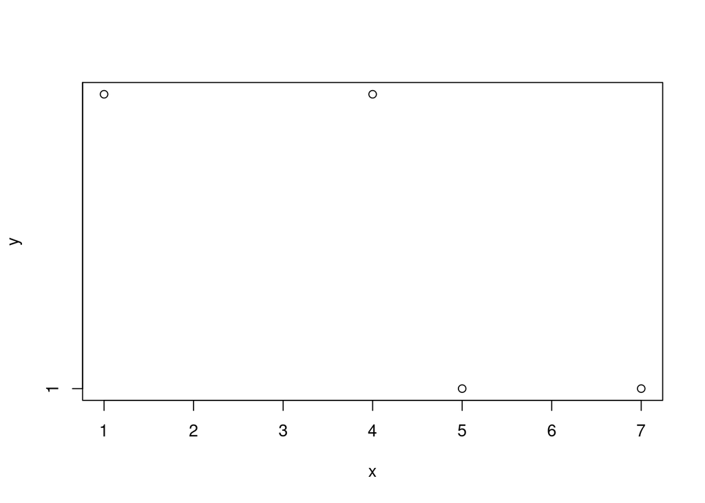

```r
#look at distribution of read counts:
y = table(partition_df$count)
x = as.numeric(names(y))
plot(x,y)
```